# MCMC gap-filling of ice core CFA data

# Compare smoothing spline/moving average of reconstructed versus simulated data

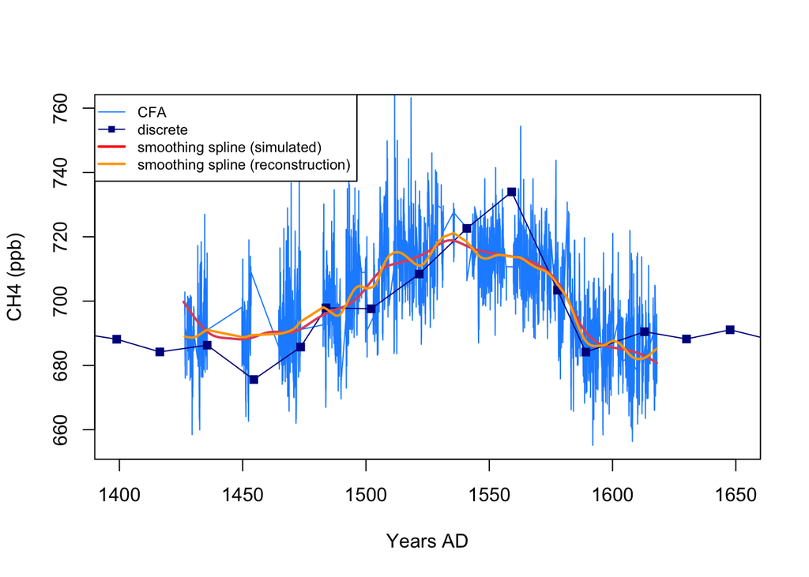

```r
# compare smoothing spline from reconstructed and simulated data
simspline <- smooth.spline(cbind(int,quant[,"50%"]), spar = 0.75) # spar: smoothing paramater
# plot results
plot(CH4_c, type='l', ylab="CH4 (ppb)", xlab="Years AD", col="dodgerblue",
     xlim=c(1400,1650), ylim=c(655, 760))
lines(CH4_d, type='o', pch=15, col="darkblue")
lines(simspline, col=2, lwd=2)
lines(myspline, col="orange", lwd=2)
legend("topleft", c("CFA","discrete", "smoothing spline (simulated)","smoothing spline (reconstruction)"), lty=c(1,1,1,1), pch=c(NA,15,NA,NA), lwd=c(1,1,2,2), col=c("dodgerblue","darkblue","red","orange"), cex=0.75)
```

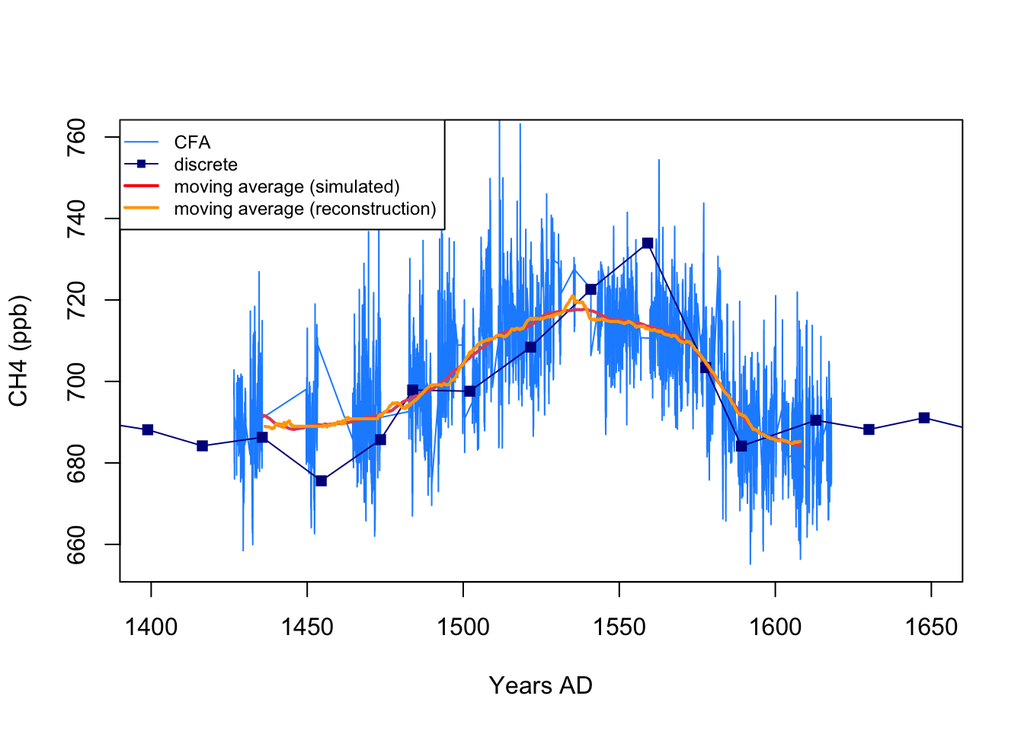

```r
#

# compare moving average from reconstructed and simulated data
simrollmean <- rollapply(quant[,"50%"], FUN=mean, width=mywidth)
simtid <- int[(mywidth:length(quant[,"50%"]))-mywidth/2] # adjusted time vector for plotting
# plot results
plot(CH4_c, type='l', ylab="CH4 (ppb)", xlab="Years AD", col="dodgerblue",
     xlim=c(1400,1650), ylim=c(655, 760))
lines(CH4_d, type='o', pch=15, col="darkblue")
lines(simtid, simrollmean, col=2, lwd=2)
lines(tid, myrollmean, col="orange", lwd=2)
legend("topleft", c("CFA","discrete", "moving average (simulated)","moving average (reconstruction)"), lty=c(1,1,1,1), pch=c(NA,15,NA,NA), lwd=c(1,1,2,2), col=c("dodgerblue","darkblue","red","orange"), cex=0.75)
```

```r
#
```

## Missing data can can produce biased estimates, leading to invalid conclusions. Now that we have imputed the missing data we have a truly continuous record and can estimate any statistical metrics increasing the statistical power of our analyses. We can apply smoothing techniques (moving average, spline, bandpass filter, LOESS etc.), perform change point analysis, piecewise linear analysis to estimate trends, etc.

## For plotting purposes only!

**Now that we have modeled the low-frequency variability of the CFA data in a continuous way, we can fill in the gaps using high-frequency noise from one surrogate AR(1)-process with the same spectral characteristics as the original CFA data, i.e. one of the many possible realizations of the CFA data**

**Since the longest interval with continuous CH4 measurements is only ~4 years, we’ll simulate a AR-process using the entirety of the non-NA CFA data rather than a very short interval with available data entries.**

```r
# invert CFA data
CFA <- CH4_c[order(CH4_c[,1]),]
# user-defined threshold length for detecting gaps
myres <- 0.03 # years (ca. 2x mean res)
# calculate time differential
dt <- abs(diff(CFA[,1]))
# index values of 'dt' larger than 'myres'
gap <- which(dt > myres)
# identify time gaps in the data
gaps_up <- CFA[-1,1][gap]
gaps_low <- CFA[-1,1][gap-1]
# merge gaps
Gaps <- c(gaps_up, gaps_low)
Gaps <- sort(Gaps)

# interpolate data at resolution MCMC model
mytime <- seq(head(CFA[,1])[1], tail(CFA[,1])[6], by=res)
# linearly interpolate CH4 data
CFA_int <- as.data.frame(approx(CFA[,1], CFA[,2], mytime))
# fill in NAs where data gaps occur
for(i in seq(1,length(Gaps),by=2)){
  CFA_int[CFA_int[,1] >= Gaps[i] & CFA_int[,1] <= Gaps[i+1], 2] <- NA
}

# Let's generate an ARIMA model
model <- auto.arima(CFA_int[,2], stationary = TRUE, parallel = TRUE, stepwise = FALSE)
```

## Use the ARIMA model to simulate a AR(1) realization of the CFA data and fill in gaps where appropriate

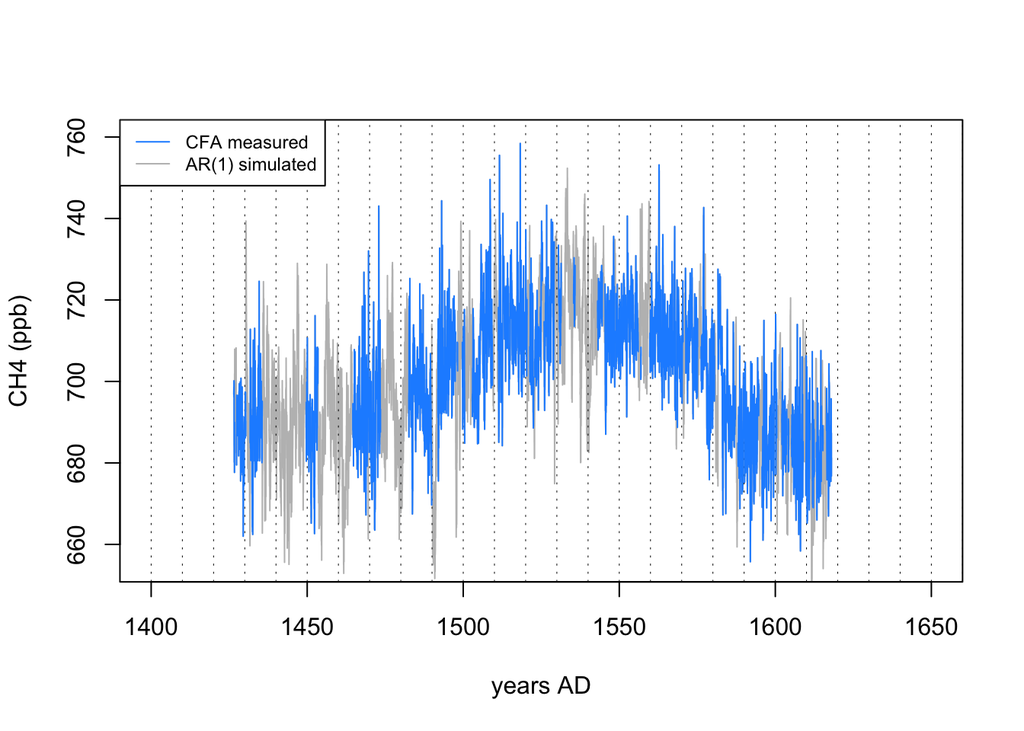

```r
# now we need the high-passed median record from the MCMC model which we will use as baseline
myfilter <- 1/20 # cutoff frequency (use the median sampling res of the discrete data)
myHP <- bandpass(cbind(int, quant[,"50%"]), fhigh = myfilter, verbose = FALSE, genplot = FALSE)
# interpolate filter at res ARIMA models
myHP_int <- as.data.frame(approx(myHP[,1], myHP[,2], CFA_int[,1]))
# index missing observations
myincomp <- which(is.na(CFA_int[,2]))
# simulate CFA data from the ARIMA model
sim <- simulate(model) # simulate an AR process from the distribution corresponding to the fitted model

# remove variability longer than 'myfilter' i.e. 20 years
sim_bp <- bandpass(cbind(CFA_int[,1], sim), flow = myfilter, verbose = FALSE, genplot = FALSE, addmean = FALSE)

# final data set combing AR-simulated and measured CFA data
myfinal <- cbind(c(CFA_int[-c(myincomp),1],myHP_int[myincomp,1]),
                   c(CFA_int[-c(myincomp),2],myHP_int[myincomp,2]+sim_bp[myincomp,2]))
# sort in increasing order
myfinal <- myfinal[order(myfinal[,1]),]

### plot measured data with filled gaps based on AR(1)-process
plot(myfinal, type='l', col="grey", ylab="CH4 (ppb)", xlab="years AD",
     xlim=c(1400,1650), ylim=c(655, 760))
abline(v=seq(1000,2000,10), lty=3, lwd=0.5)
lines(CFA_int, col="dodgerblue")
legend("topleft", c("CFA measured", "AR(1) simulated"), lty=c(1,1), col=c("dodgerblue", "grey"), cex=0.75)
```

## Save results on table

```r
###################
write.table(myfinal,file="ST_CH4_cont_AR1.txt", row.names=FALSE,
            col.names=c("Gas_Age_yrsAD","CH4_ppb"))
```